# Taller 1 Multivariado

Diego Torres

Febrero de 2020

### **Estudio climatico**

Se tiene una base de datos mensual entre mayo de 1983 y diciembre de 2008 con informacion relacionada a contaminación del aire a nivel global, en donde se tienen datos de concentraciones de contaminantes, medidas de temperatura, indices, etc.La descripción de las variables es la siguiente:

**Year:** el año de la observacion.  
**Month:** el mes de la observacion.  
**Temp:** la diferencia en grados centigrados entre la temperatura promedio global en ese periodo y el valor de referencia. Estos datos fueron suministrados por la Unidad de Investigacion Climatica de la University of East Anglia.  
**CO2, N2O, CH4, CFC.11, CFC.12:** concentraciones atmosfericas de dioxido de carbono (CO2), oxido nitroso (N2O), metano (CH4), triclorofluorometano (CCl3F; mas conocido como CFC-11) and diclorodifluorometano (CCl2F2; mas conocido como CFC-12), respectivamente. CFC.11 y CFC.12 son expresadas en ppbv (partes por billon de volumen), mientras que CO2, N2O y CH4 son expresados en ppmv (partes por millon de volumen, es decir, 397 ppmv de CO2 significa que ese CO2 constituye 397 millonesimas partes del volumen total de la atmosfera). Estos datos provienen de ESRL/NOAA Division Global de Monitoreo.  
**Aerosols:** la profundidad óptica media del aerosol estratosferico a 550 nm. Esta variable es asociada a la actividad volcanica y al material piroclastico acomulado en la atmosfera, lo cual afecta la cantidad de energía solar que es reflejada de vuelta al espacio. Los datos fueron suministrados por el Instituto Godard de Estudios Espaciales de la NASA.  
**TSI:** el total de irradiacion solar (TSI) en W/m2 (la tasa a la que la energia del sol es depositada por unidad de area). Debido a las manchas solares y otros fenomenos similares, la cantidad de energia emitida por el sol varia sustancialmente con el tiempo. La información fue obtenida de el proyecto web SOLARIS-HEPPA.  
**MEI:** indice multivariado de oscilación meridional de El Niño (MEI), una medida que indica la fuerza de oscilación de los fenomenos de El Nino/La Nina en el hemisferio sur (Son fenomenos climáticos que ocurren en el pacifico sur que afecta temperaturas globales). Los datos provienen del ESRL/NOAA División de Ciencias Fisicas.  
A continuación, un resumen de los datos.

```
## 'data.frame':    308 obs. of  11 variables:
##  $ Year    : Factor w/ 26 levels "1983","1984",..: 1 1 1 1 1 1 1 1 2 2 ...
##  $ Month   : Factor w/ 12 levels "1","2","3","4",..: 5 6 7 8 9 10 11 12 1 2 ...
##  $ MEI     : num  2.556 2.167 1.741 1.13 0.428 ...
##  $ CO2     : num  346 346 344 342 340 ...
##  $ CH4     : num  1639 1634 1633 1631 1648 ...
##  $ N2O     : num  304 304 304 304 304 ...
##  $ CFC.11  : num  191 192 193 194 194 ...
##  $ CFC.12  : num  350 352 354 356 357 ...
##  $ TSI     : num  1366 1366 1366 1366 1366 ...
##  $ Aerosols: num  0.0863 0.0794 0.0731 0.0673 0.0619 0.0569 0.0524 0.0486 0.0451 0.0416 ...
##  $ Temp    : num  0.109 0.118 0.137 0.176 0.149 0.093 0.232 0.078 0.089 0.013 ...
## NULL
```

```
##       Year         Month          MEI               CO2
##  1984   : 12   5      : 26   Min.   :-1.6350   Min.   :340.2
##  1985   : 12   6      : 26   1st Qu.:-0.3987   1st Qu.:353.0
##  1986   : 12   7      : 26   Median : 0.2375   Median :361.7
##  1987   : 12   8      : 26   Mean   : 0.2756   Mean   :363.2
##  1988   : 12   9      : 26   3rd Qu.: 0.8305   3rd Qu.:373.5
##  1989   : 12   10     : 26   Max.   : 3.0010   Max.   :388.5
##  (Other):236   (Other):152
##       CH4            N2O            CFC.11          CFC.12
##  Min.   :1630   Min.   :303.7   Min.   :191.3   Min.   :350.1
##  1st Qu.:1722   1st Qu.:308.1   1st Qu.:246.3   1st Qu.:472.4
##  Median :1764   Median :311.5   Median :258.3   Median :528.4
##  Mean   :1750   Mean   :312.4   Mean   :252.0   Mean   :497.5
##  3rd Qu.:1787   3rd Qu.:317.0   3rd Qu.:267.0   3rd Qu.:540.5
##  Max.   :1814   Max.   :322.2   Max.   :271.5   Max.   :543.8
##
##       TSI          Aerosols            Temp
##  Min.   :1365   Min.   :0.00160   Min.   :-0.2820
##  1st Qu.:1366   1st Qu.:0.00280   1st Qu.: 0.1217
##  Median :1366   Median :0.00575   Median : 0.2480
##  Mean   :1366   Mean   :0.01666   Mean   : 0.2568
##  3rd Qu.:1366   3rd Qu.:0.01260   3rd Qu.: 0.4073
##  Max.   :1367   Max.   :0.14940   Max.   : 0.7390
##
```

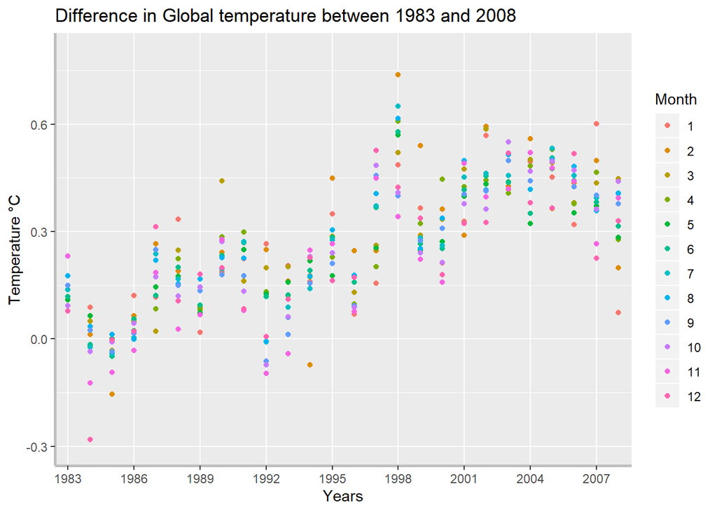

```r
library(ggplot2)
ggplot(data, aes(x = Year, y = Temp, colour = Month)) +
  geom_point() +
  scale_x_discrete(name="Years", breaks = c(seq(1983, 2008, 3))) +
  scale_y_continuous(name="Temperature °C", limits=c(-0.3, 0.8)) +
  theme(axis.line = element_line(colour = "grey",
                      size = 1, linetype = "solid")) +
  ggtitle("Difference in Global temperature between 1983 and 2008")
```

El grafico indica una marcada tendencia de ascenso de los niveles de temperatura mundial con respecto a un valor de referencia, los colores son dados por el promedio mensual de cada año, mostrando que los primeros meses del año suelen ser más calidos.Vamos a ver la insidencia de algunos contaminantes y otros fenómenos climaticos en la prediccion de estos ascensos de la temperatura.

Ahora, vamos a ver la relacion entre las demas variables cualitativas.Para esto, se obtendrá la matriz de covarianza, la cual nos permite ver la varianza de cada variable en la diagonal principal. Mientras que los demás valores son la covarianza e indican la relación de dependencia entre cada par de variables de la matriz. Si ambas aumentan o disminuyen, la covarianza es positiva, mientras que si una variable tiende a aumentar y la otra no, la covarianza sera negativa. La covarianza es similar a la correlación, pero cuando esta ultima se calcula, los datos están estandarizados. Por lo tanto, la covarianza se expresa en unidades que varían con los datos y no se convierte a una escala estandarizada de 1 negativo a +1 como sí ocurre en la correlación.

```r
library(dplyr)
data. <- select(data, MEI:Temp)
round(cov(data.), 3)
```

```
##             MEI     CO2      CH4     N2O  CFC.11   CFC.12    TSI Aerosols
## MEI       0.880  -1.814   -4.559  -0.796   1.673   -2.161 -0.029    0.010
## CO2      -1.814 159.950  508.019  64.836 102.678  602.050  0.090   -0.136
## CH4      -4.559 508.019 2120.757 215.218 664.777 2551.810  2.693   -0.388
## N2O      -0.796  64.836  215.218  27.302  43.570  253.596  0.083   -0.054
## CFC.11    1.673 102.678  664.777  43.570 409.325  972.667  2.301   -0.019
## CFC.12   -2.161 602.050 2551.810 253.596 972.667 3343.950  4.374   -0.410
## TSI      -0.029   0.090    2.693   0.083   2.301    4.374  0.160    0.001
## Aerosols  0.010  -0.136   -0.388  -0.054  -0.019   -0.410  0.001    0.001
## Temp      0.023   1.695    5.771   0.696   1.377    7.135  0.013   -0.002
##            Temp
## MEI       0.023
## CO2       1.695
## CH4       5.771
## N2O       0.696
## CFC.11    1.377
## CFC.12    7.135
## TSI       0.013
## Aerosols -0.002
## Temp      0.032
```

Se observa de la matriz que hay una fuerte relación de dependencia entre los contaminantes principales de la atmosfera. Para mirar un poco más la relación de dependencia, utilizaremos un grafico de correlación.Posteriormente, un grafico que nos indicara la distribucion de cada variable, el valor de la correlación y si es significante o no.

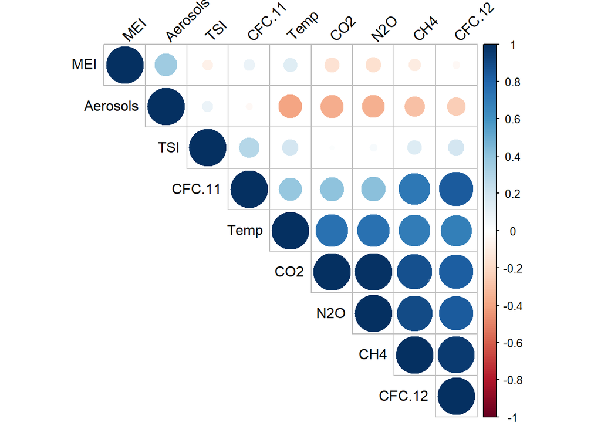

```r
library(corrplot)
corrplot(cor(data.), type = "upper", order = "hclust",
         tl.col = "black", tl.srt = 45)
```

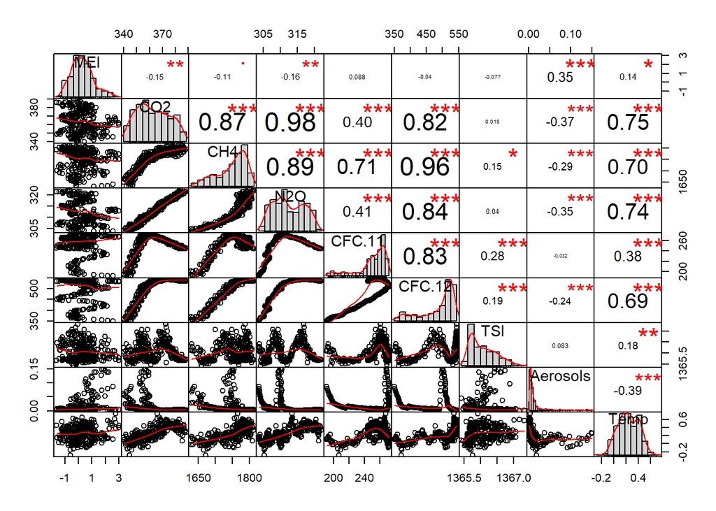

```r
library("PerformanceAnalytics")
chart.Correlation(data., histogram=TRUE, pch=19)
```

#### **Dioxido de carbono CO2**

```r
summary(data$CO2)
```

```
##    Min. 1st Qu.  Median    Mean 3rd Qu.    Max.
##   340.2   353.0   361.7   363.2   373.5   388.5
```

Ahora veamos la distribución y el plot de densidad:

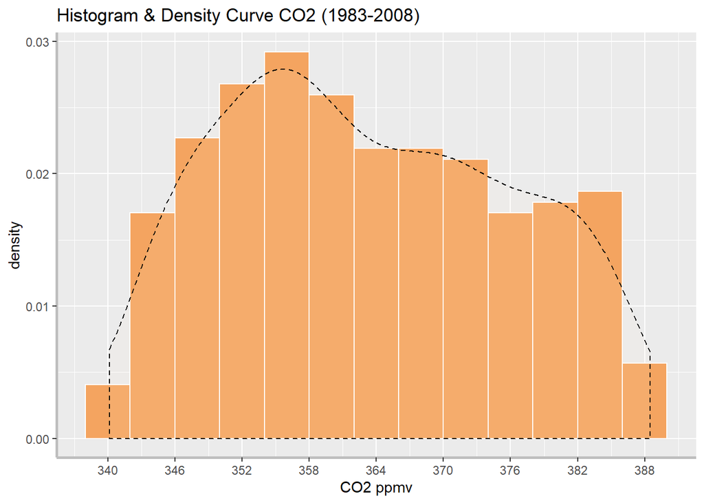

```r
ggplot(data, aes(x = data$CO2)) +
  geom_histogram(binwidth=4, color="white", fill="sandybrown", aes(y=..density..)) +
  geom_density(stat="density", alpha=I(0.1), fill="papayawhip", lty=2) +
  scale_x_continuous(name="CO2 ppmv", breaks = c(seq(340, 390, 6))) +
  theme(axis.line = element_line(colour = "grey",
                      size = 1, linetype = "solid")) +
  ggtitle("Histogram & Density Curve CO2 (1983-2008)")
```

Aplicamos test de Shapiro-Wilks para determinar normalidad en los datos:

```r
#Normalidad
shapiro.test(data$CO2)
```

```
##
##  Shapiro-Wilk normality test
##
## data:  data$CO2
## W = 0.96349, p-value = 5.401e-07
```

H0: las muestras provienen de una distribución normal.  
H1: las muestras no provienen de una distribución normal.

Según Royston (1995), el valor del p-valor es adecuado para valores menores a 0.1, sin embargo, el test de shapiro es contra la normalidad en los datos, por lo tanto, al ser el p-valor menor al nivel de significancia, entonces se rechaza la hipotesis de que provienen de una distribución normal.

Ahora, obtendremos el diagrama de tallo y hojas que nos ayudará a visualizar de manera más numérica la distribución.

```r
stem(data$CO2)
```

```
##
##   The decimal point is at the |
##
##   340 | 23457
##   342 | 311122
##   344 | 12455890355689
##   346 | 01155778012678
##   348 | 011244790127899
##   350 | 02345733445667
##   352 | 123368999123778889
##   354 | 01123399991345566779
##   356 | 1123389991334468
##   358 | 011245900113344556699
##   360 | 236788834778
##   362 | 0224022258
##   364 | 0123345599224568
##   366 | 0377990117
##   368 | 012234600335566779
##   370 | 35567802556788
##   372 | 25511224789
##   374 | 013469056799
##   376 | 2577005679
##   378 | 23557792689
##   380 | 2456891148
##   382 | 0222445790189
##   384 | 1125670467
##   386 | 0144629
##   388 | 5
```

Ahora, observaremos como ha variado el dioxido de carbono a traves de los años según los datos:

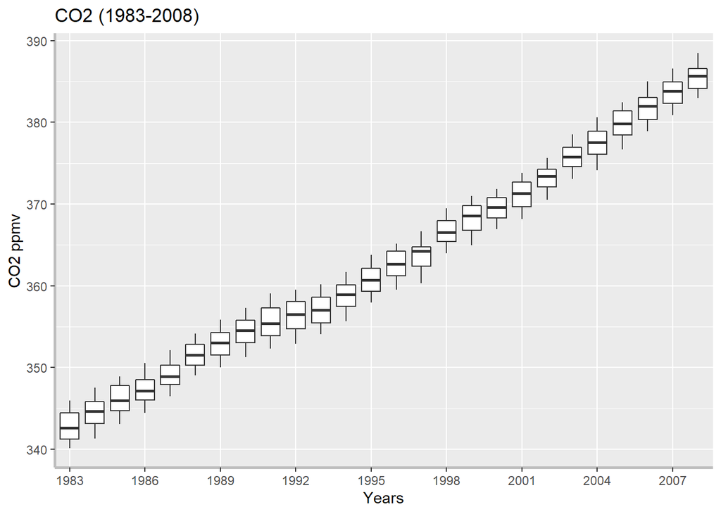

```r
ggplot(data, aes(x = data$Year, y = data$CO2)) +
  geom_boxplot() +
  scale_x_discrete(name="Years", breaks = c(seq(1980, 2008, 3))) +
  scale_y_continuous(name="CO2 ppmv") +
  theme(axis.line = element_line(colour = "grey",
                      size = 1, linetype = "solid")) +
  ggtitle("CO2 (1983-2008)")
```

#### **Oxido nitroso N2O**

```r
summary(data$N2O)
```

```
##    Min. 1st Qu.  Median    Mean 3rd Qu.    Max.
##   303.7   308.1   311.5   312.4   317.0   322.2
```

Ahora veamos la distribución y el plot de densidad:

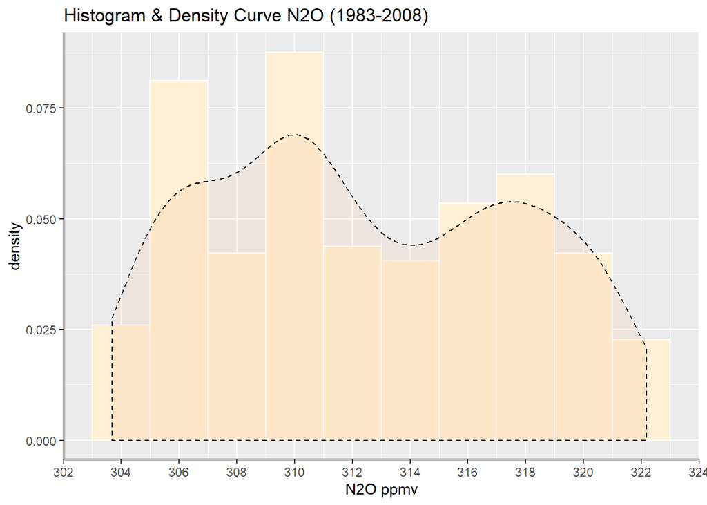

```r
ggplot(data, aes(x = data$N2O)) +
  geom_histogram(binwidth=2, color="white", fill="papayawhip", aes(y=..density..)) +
  geom_density(stat="density", alpha=I(0.1), fill="sandybrown", lty=2) +
  scale_x_continuous(name="N2O ppmv", breaks = c(seq(300, 325, 2))) +
  theme(axis.line = element_line(colour = "grey",
                      size = 1, linetype = "solid")) +
  ggtitle("Histogram & Density Curve N2O (1983-2008)")
```

Aplicamos test de Shapiro-Wilks para determinar normalidad en los datos:

```r
#Normalidad
shapiro.test(data$N2O)
```

```
##
##  Shapiro-Wilk normality test
##
## data:  data$N2O
## W = 0.95066, p-value = 1.177e-08
```

H0: las muestras provienen de una distribución normal.  
H1: las muestras no provienen de una distribución normal.

Al ser el p-valor menor al nivel de significancia, entonces se rechaza la hipotesis de que provienen de una distribución normal.

Ahora, obtendremos el diagrama de tallo y hojas que nos ayudará a visualizar de manera más numérica la distribución.

```r
stem(data$N2O)
```

```
##
##   The decimal point is at the |
##
##   303 | 77889
##   304 | 00112345679
##   305 | 0000112223333445578899
##   306 | 1111223444455555666667788999
##   307 | 3466677788
##   308 | 024455666777789
##   309 | 001124444455557779
##   310 | 0000111111122222222333344455778889999
##   311 | 1122345556777889
##   312 | 04455666778
##   313 | 0022334555679
##   314 | 234445566679
##   315 | 01122246899
##   316 | 00111222233357889999
##   317 | 0000122234666678
##   318 | 01111112222356889999999
##   319 | 135788899999
##   320 | 01333455556669
##   321 | 123334444458
##   322 | 02
```

Ahora, observaremos como ha variado el oxido nitroso a traves de los años según los datos:

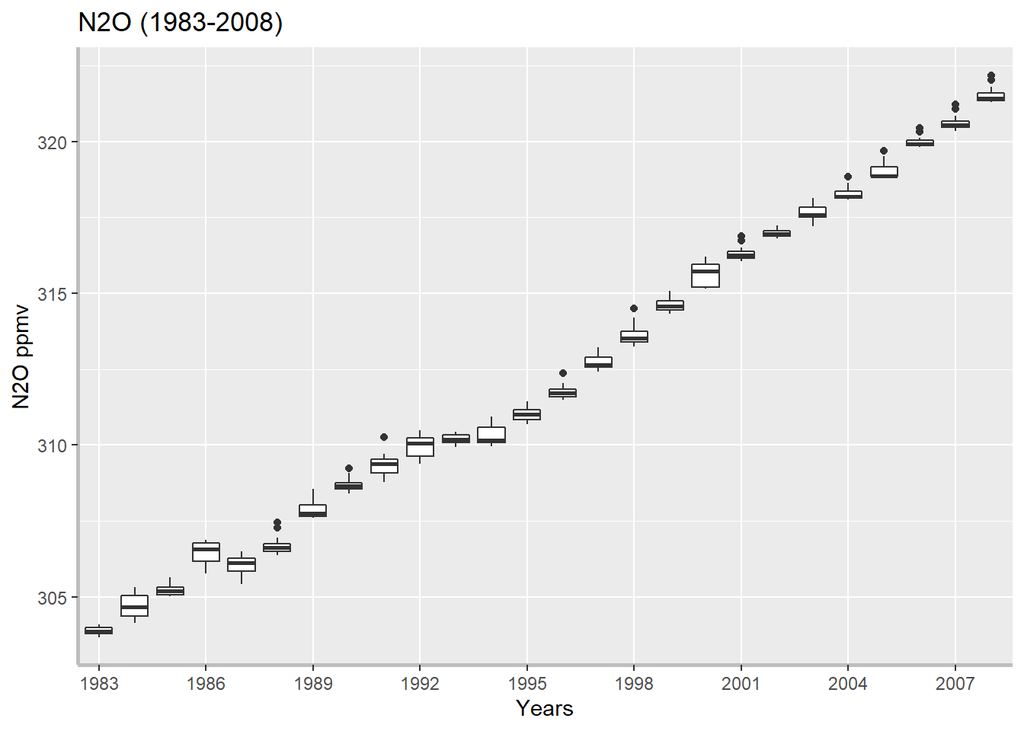

```r
ggplot(data, aes(x = data$Year, y = data$N2O)) +
  geom_boxplot() +
  scale_x_discrete(name="Years", breaks = c(seq(1980, 2008, 3))) +
  scale_y_continuous(name="N2O ppmv") +
  theme(axis.line = element_line(colour = "grey",
                      size = 1, linetype = "solid")) +
  ggtitle("N2O (1983-2008)")
```

Se puede observar que la variación mensual de las concentraciones en volumen de N2O varia poco, pero cuando se compara entre años, las diferencias son muy significativas.

Ahora bien, para finalizar realizaremos un modelo de predicción de la variable temperatura a partir del resto de variables.

```r
model <- lm(Temp ~ ., data = data.)
summary(model)
```

```
##
## Call:
## lm(formula = Temp ~ ., data = data.)
##
## Residuals:
##      Min       1Q   Median       3Q      Max
## -0.26228 -0.05868  0.00051  0.05718  0.32170
##
## Coefficients:
##               Estimate Std. Error t value Pr(>|t|)
## (Intercept) -1.277e+02  1.919e+01  -6.654 1.36e-10 ***
## MEI          6.632e-02  6.186e-03  10.722  < 2e-16 ***
## CO2          5.207e-03  2.192e-03   2.375   0.0182 *
## CH4          6.371e-05  4.977e-04   0.128   0.8982
## N2O         -1.693e-02  7.835e-03  -2.161   0.0315 *
## CFC.11      -7.278e-03  1.461e-03  -4.980 1.07e-06 ***
## CFC.12       4.272e-03  8.763e-04   4.875 1.77e-06 ***
## TSI          9.586e-02  1.401e-02   6.844 4.38e-11 ***
## Aerosols    -1.582e+00  2.099e-01  -7.535 5.86e-13 ***
## ---
## Signif. codes:  0 '***' 0.001 '**' 0.01 '*' 0.05 '.' 0.1 ' ' 1
##
## Residual standard error: 0.09182 on 299 degrees of freedom
## Multiple R-squared:  0.744,  Adjusted R-squared:  0.7371
## F-statistic: 108.6 on 8 and 299 DF,  p-value: < 2.2e-16
```

Del modelo anterior, obtenemos que las variables contaminantes como CO2, CH4 y N2O son las menos significativas, quizas porque la información que estas aportan al modelo es redundante, debido a su alta correlación.

```r
model <- lm(Temp ~ .-N2O-CH4-CO2, data = data.)
summary(model)
```

```
##
## Call:
## lm(formula = Temp ~ . - N2O - CH4 - CO2, data = data.)
##
## Residuals:
##      Min       1Q   Median       3Q      Max
## -0.26695 -0.06084  0.00119  0.05607  0.32378
##
## Coefficients:
##               Estimate Std. Error t value Pr(>|t|)
## (Intercept) -1.272e+02  1.913e+01  -6.651 1.36e-10 ***
## MEI          6.777e-02  6.132e-03  11.052  < 2e-16 ***
## CFC.11      -6.200e-03  5.104e-04 -12.147  < 2e-16 ***
## CFC.12       3.656e-03  1.791e-04  20.412  < 2e-16 ***
## TSI          9.313e-02  1.402e-02   6.644 1.42e-10 ***
## Aerosols    -1.660e+00  2.086e-01  -7.960 3.50e-14 ***
## ---
## Signif. codes:  0 '***' 0.001 '**' 0.01 '*' 0.05 '.' 0.1 ' ' 1
##
## Residual standard error: 0.09235 on 302 degrees of freedom
## Multiple R-squared:  0.7385, Adjusted R-squared:  0.7341
## F-statistic: 170.5 on 5 and 302 DF,  p-value: < 2.2e-16
```